# Prediction Assignment Writeup

O.S.

16 November 2018

## Executive Summary

Using devices such as Jawbone Up, Nike FuelBand, and Fitbit it is now possible to collect a large amount of data about personal activity relatively inexpensively. The purpose of this exercise is to use the data to try and predict five type of activities (the way they did the training)

Libraries

```r
library(ggplot2)
library(caret)
library(gbm)
library(parallel)
library(doParallel)
library(dplyr)
library(rpart)
library(rpart.plot)
```

## Load Data

Loading the data.

```r
training = read.csv("E:/Elements/Coursera/Data Sciense/Course 8 - Practical Machine Learning/Project/pml-training.csv")

validiation = read.csv("E:/Elements/Coursera/Data Sciense/Course 8 - Practical Machine Learning/Project/pml-testing.csv")
```

### Data observation

```r
dim(training)
```

```
## [1] 19622   160
```

The training dataset contains 19622 observations and 160 variables.

```r
dim(validiation)
```

```
## [1]  20 160
```

The validation set is 20 observations over 160 variables.

## Data cleaning

Calculate the NA percentage.

```r
NAnoTrain<-sum(is.na(training))
NAtrainPercentage<-NAnoTrain/(ncol(training)*nrow(training))
NAnoValidiation<-sum(is.na(validiation))
NAValidiationPercentage<-NAnoValidiation/(ncol(validiation)*nrow(validiation))
print(NAtrainPercentage)
```

```
## [1] 0.4100856
```

```r
print(NAValidiationPercentage)
```

```
## [1] 0.625
```

t can be sen there is a large number of NA values. In the Training set,0.41 of the data is NA. In the Validation set, 0.625 of the information is NA.

The approach is to check if a column contains more the 80% NA either in training or in the validation set and remove it from both sets (if true).

```r
#Calculate the percentage of the NA in each column
#and remove the columns which
#have more than 80% NA - Training
TrainColNAPrec<-training %>%
   summarise_all(funs(100*mean(is.na(.))))
TrainColToRemove<-names(TrainColNAPrec[,TrainColNAPrec>80])


#Calculate the percentage of the NA in each column
#and remove the columns which
#have more than 80% NA - Validation
ValidiationColNAPrec<-validiation %>%
   summarise_all(funs(100*mean(is.na(.))))
ValidiationToRemove<-names(ValidiationColNAPrec[,ValidiationColNAPrec>80])

#Bind the column's names (If the NA percentage is above 80% in
#one of the set remove the columns from both sets
ColToRemove<-unique(c(TrainColToRemove,ValidiationToRemove))
ColToKeep<-!(names(training) %in% ColToRemove)
Training<-training[ ,ColToKeep]
Validiation<-validiation[ ,ColToKeep]
```

Remove the names data and the timestamps related columns As they will not contribute to the prediction.

```r
trainRemove <- grepl("^X|timestamp|window", names(Training))
Training <- Training[, !trainRemove]

ValidiationRemove <- grepl("^X|timestamp|window", names(Validiation))
Validiation <- Validiation[, !ValidiationRemove]
print(dim(Training))
```

```
## [1] 19622    54
```

```r
print(dim(Validiation))
```

```
## [1] 20 54
```

There are 54 columns left for the Training and Validation.

## Modeling

The model that will be tested are :

GBM - (Gradient Boosting Machine) (Boosting with Trees). RF - Random Forests.

Split the Training set into train and test sets.

```r
set.seed(123444) # For reproducibile purpose
inTrain <- createDataPartition(Training$classe, p=0.70, list=F)
trainData <- Training[inTrain, ]
testData <- Training[-inTrain, ]
```

## GBM Model

```r
#Use parallel processing to train the model.
cluster <- makeCluster(detectCores() - 1) # convention to leave 1 core for OS
registerDoParallel(cluster)
fitControl <- trainControl(method = "cv",
                           number = 5,
                           allowParallel = TRUE)
```

Train the model.

```r
set.seed(13444)
gbmfit <- train(as.factor(classe)~., method="gbm",data=trainData,trControl = fitControl,verbose = FALSE)
```

Stop parallel processing.

```r
stopCluster(cluster)
registerDoSEQ()
```

Predict using the test data to calculate the accuracy.

```r
gbmpred <- predict(gbmfit,testData)
gbmaccuracy <- confusionMatrix(gbmpred,testData$classe)$overall['Accuracy']
```

## RF Model

```r
#Use parallel processing to train the model.
cluster <- makeCluster(detectCores() - 1) # convention to leave 1 core for OS
registerDoParallel(cluster)
fitControl <- trainControl(method = "cv",
                           number = 5,
                           allowParallel = TRUE)
```

Train the model.

```r
set.seed(13444)
RFfit <- train(as.factor(classe)~., method="rf",data=trainData,trControl = fitControl)
```

Stop parallel processing.

```r
stopCluster(cluster)
registerDoSEQ()
```

Predict using the test data to calculate the accuracy.

```r
RFpred <- predict(RFfit,testData)
RFaccuracy <- confusionMatrix(RFpred,testData$classe)$overall['Accuracy']
```

Results:

```r
cat("GBM Accuercy:",gbmaccuracy)
```

```
## GBM Accuercy: 0.9617672
```

```r
cat("RF Accuercy:",RFaccuracy)
```

```
## RF Accuercy: 0.9935429
```

The Random Forest model provides the best accuracy on the test set Here are the model parameters.

```r
RFfit
```

```
## Random Forest
##
## 13737 samples
##    53 predictor
##     5 classes: 'A', 'B', 'C', 'D', 'E'
##
## No pre-processing
## Resampling: Cross-Validated (5 fold)
## Summary of sample sizes: 10990, 10990, 10988, 10990, 10990
## Resampling results across tuning parameters:
##
##   mtry  Accuracy   Kappa
##    2    0.9887173  0.9857256
##   29    0.9898092  0.9871071
##   57    0.9815830  0.9766976
##
## Accuracy was used to select the optimal model using the largest value.
## The final value used for the model was mtry = 29.
```

Predict (Validation) using the Random Forest model.

```r
predict(RFfit,newdata = Validiation)
```

```
##  [1] B A B A A E D B A A B C B A E E A B B B
## Levels: A B C D E
```

## Appendix

Table of the 20 most important variables in the random forest model.

```r
varImp(RFfit)
```

```
## rf variable importance
##
##   only 20 most important variables shown (out of 57)
##
##                      Overall
## roll_belt             100.00
## pitch_forearm          59.81
## yaw_belt               54.47
## magnet_dumbbell_y      44.62
## roll_forearm           44.07
## pitch_belt             43.90
## magnet_dumbbell_z      43.14
## accel_dumbbell_y       24.32
## accel_forearm_x        19.16
## roll_dumbbell          18.16
## magnet_dumbbell_x      18.01
## magnet_belt_z          16.29
## magnet_forearm_z       15.33
## accel_dumbbell_z       14.81
## total_accel_dumbbell   14.77
## magnet_belt_y          14.66
## accel_belt_z           14.11
## yaw_arm                11.45
## gyros_belt_z           11.35
## magnet_belt_x          10.60
```

Visualizing the decision tree.

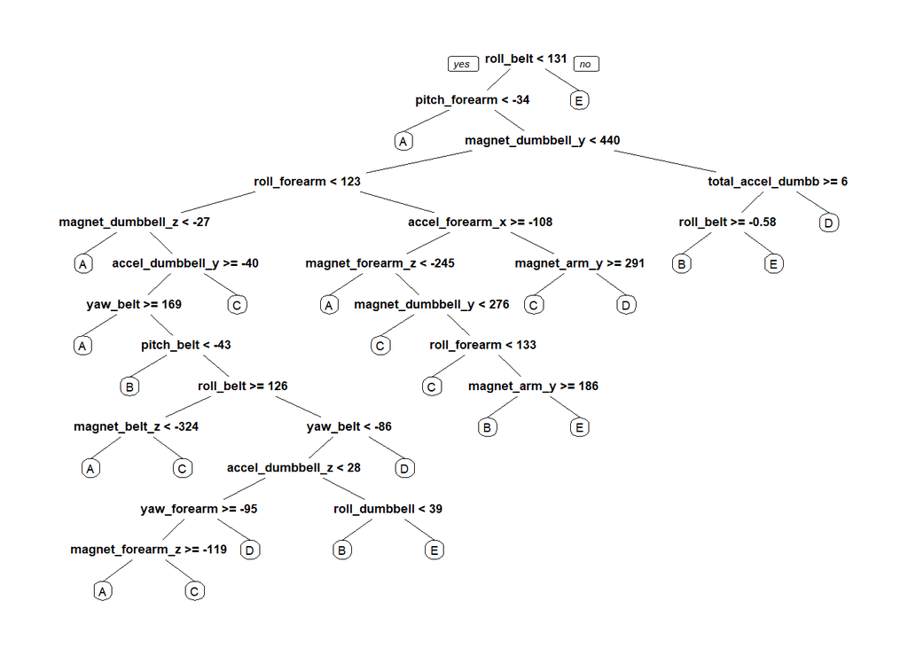

```r
treeModel <- rpart(classe ~ ., data=trainData, method="class")
prp(treeModel) # fast plot
```